Analisis Komprehensif Performa Industri Film dan Segmentasi Pelanggan Menggunakan Metode *Multiple Linear Regression* dan *Hierarchical Clustering*

Penulis: Roby Alvianto

---

Analisis data yang bertujuan untuk mengetahui performa produk, dinamika transaksi pada sistem penjualan industri retail, dan memahami pola perilaku pelanggan berbasis data sakila. Data sakila merupakan dataset *open source* pada instalasi MySQL yang merepresentasikan skenario toko penyewaan film. Data sakila dipilih karena struktur relasionalnya yang cukup lengkap dan representatif untuk studi kasus bisnis pada industri retail atau layanan. Tabel yang tersedia, seperti *customer, rental, payment, film,* dan *inventory.*. Dataset ini memungkinkan dapat menjawab pertanyaan operasional.

### Mengambil Data dari Database

Langkah pertama adalah *import* dataset sakila ke dalam database. Setelah selesai *import*, selanjutnya membuat koneksi baru dengan database yang dimasukkan ke dalam object dengan nama "conn". Jika koneksi dengan database telah berhasil terhubung, query untuk mendapatkan data.

```r
dbListTables(conn)
```

```
##  [1] "actor"                      "actor_info"
##  [3] "address"                    "category"
##  [5] "city"                       "country"
##  [7] "customer"                   "customer_list"
##  [9] "film"                       "film_actor"
## [11] "film_category"              "film_list"
## [13] "film_text"                  "inventory"
## [15] "language"                   "nicer_but_slower_film_list"
## [17] "payment"                    "rental"
## [19] "sales_by_film_category"     "sales_by_store"
## [21] "staff"                      "staff_list"
## [23] "store"                      "time_ref_metadata"
```

```r
exec.summary <-dbGetQuery(
  conn = conn,
  statement = 'SELECT
                  SUM(p.amount) AS \'Total Revenue\',
                  AVG(p.amount) AS \'Average per Transactions\',
                  COUNT(r.rental_id) AS \'Total Rental\'
               FROM payment AS p
               INNER JOIN rental AS r ON p.rental_id = r.rental_id'
)

trend <-dbGetQuery(
  conn = conn,
  statement = 'SELECT
                  r.rental_date AS \'Rental Date\',
                  COUNT(r.rental_id) AS \'Total Rental\',
                  SUM(p.amount) AS \'Total Revenue\'
               FROM rental AS r
               INNER JOIN payment AS p ON r.rental_id = p.rental_id
               GROUP BY r.rental_date'
)

category.film <-dbGetQuery(
  conn = conn,
  statement = 'WITH comb AS(
                  SELECT
                      c.name AS category,
                      i.inventory_id AS inventory_id
                  FROM category AS c
                  INNER JOIN film_category AS fc ON c.category_id = fc.category_id
                  INNER JOIN film AS f ON fc.film_id = f.film_id
                  INNER JOIN inventory AS i ON f.film_id = i.film_id
               )
               SELECT
                  c.category AS Category,
                  r.rental_id AS \'Rental ID\',
                  p.amount AS Amount
               FROM comb AS c
               INNER JOIN rental AS r ON c.inventory_id = r.inventory_id
               INNER JOIN payment AS p ON r.rental_id = p.rental_id'
)

film.actor <-dbGetQuery(
  conn = conn,
  statement = 'WITH film_actor AS(
                  SELECT
                      f.title AS title,
                      CONCAT(a.first_name, \' \', a.last_name) AS actor,
                      i.inventory_id AS inventory_id
                  FROM film AS f
                  INNER JOIN film_actor AS fc ON f.film_id = fc.film_id
                  INNER JOIN actor AS a ON fc.actor_id = a.actor_id
                  INNER JOIN inventory AS i ON f.film_id = i.film_id
               )
               SELECT
                  fa.title AS Title,
                  fa.actor AS Actor,
                  r.rental_id AS \'Rental ID\',
                  p.amount AS Amount
               FROM film_actor AS fa
               INNER JOIN rental AS r ON fa.inventory_id = r.inventory_id
               INNER JOIN payment AS p ON r.rental_id = p.rental_id'
)

dbExecute(
  conn = conn,
  statement = 'SET @time_ref = \'2006-03-01 00:00:00\''
)

segment <-dbGetQuery(
  conn = conn,
  statement = 'SELECT
                  c.customer_id AS \'Customer ID\',
                  CONCAT(c.first_name, \' \', c.last_name) AS \'Customer Name\',
                  c.active AS Status,
                  MAX(r.rental_date) AS \'Last Rental Date\',
                  DATEDIFF(CAST(@time_ref AS DATETIME), MAX(r.rental_date)) AS \'Recency Date\',
                  COUNT(DISTINCT(r.rental_id)) AS Frequency,
                  SUM(p.amount) AS Monetary
               FROM customer AS c
               INNER JOIN rental AS r ON c.customer_id = r.customer_id
               INNER JOIN payment AS p ON c.customer_id = p.customer_id
               GROUP BY c.customer_id'
)

store <-dbGetQuery(
  conn = conn,
  statement = 'WITH loc AS(
                  SELECT
                      s.store_id AS store_id,
                      a.address AS address,
                      c.city AS city,
                      co.country AS country
                  FROM store AS s
                  INNER JOIN address AS a ON s.address_id = a.address_id
                  INNER JOIN city AS c ON a.city_id = c.city_id
                  INNER JOIN country AS co ON c.country_id = co.country_id
               )
               SELECT
                  l.store_id AS \'Store ID\',
                  l.address AS Address,
                  l.city AS City,
                  l.country AS Country,
                  COUNT(p.payment_id) AS \'Transaction Frequency\',
                  SUM(p.amount) AS \'Total Transaction\'
               FROM loc AS l
               INNER JOIN customer AS c ON l.store_id = c.store_id
               INNER JOIN payment AS p ON c.customer_id = p.customer_id
               GROUP BY l.store_id'
)
```

```r
glimpse(exec.summary)
```

```
## Rows: 1
## Columns: 3
## $ `Total Revenue`            <dbl> 67406.56
## $ `Average per Transactions` <dbl> 4.201356
## $ `Total Rental`             <dbl> 16044
```

```r
glimpse(trend)
```

```
## Rows: 15,815
## Columns: 3
## $ `Rental Date`   <chr> "2005-05-25 11:30:37", "2005-05-28 10:35:23", "2005-06…
## $ `Total Rental`  <dbl> 1, 1, 1, 1, 1, 1, 1, 1, 1, 1, 1, 1, 1, 1, 1, 1, 1, 1, …
## $ `Total Revenue` <dbl> 2.99, 0.99, 5.99, 0.99, 9.99, 4.99, 4.99, 0.99, 3.99, …
```

```r
glimpse(category.film)
```

```
## Rows: 16,044
## Columns: 3
## $ Category    <chr> "Action", "Action", "Action", "Action", "Action", "Action"…
## $ `Rental ID` <int> 10895, 12268, 3150, 5072, 9080, 14603, 588, 2867, 6030, 77…
## $ Amount      <dbl> 0.99, 0.99, 0.99, 3.99, 1.99, 1.99, 0.99, 0.99, 0.99, 0.99…
```

```r
glimpse(film.actor)
```

```
## Rows: 87,980
## Columns: 4
## $ Title       <chr> "ACADEMY DINOSAUR", "ACADEMY DINOSAUR", "ACADEMY DINOSAUR"…
## $ Actor       <chr> "PENELOPE GUINESS", "CHRISTIAN GABLE", "LUCILLE TRACY", "S…
## $ `Rental ID` <int> 4863, 4863, 4863, 4863, 4863, 4863, 4863, 4863, 4863, 4863…
## $ Amount      <dbl> 0.99, 0.99, 0.99, 0.99, 0.99, 0.99, 0.99, 0.99, 0.99, 0.99…
```

```r
glimpse(segment)
```

```
## Rows: 599
## Columns: 7
## $ `Customer ID`      <dbl> 1, 2, 3, 4, 5, 6, 7, 8, 9, 10, 11, 12, 13, 14, 15, …
## $ `Customer Name`    <chr> "MARY SMITH", "PATRICIA JOHNSON", "LINDA WILLIAMS",…
## $ Status             <int> 1, 1, 1, 1, 1, 1, 1, 1, 1, 1, 1, 1, 1, 1, 1, 0, 1, …
## $ `Last Rental Date` <chr> "2005-08-22 20:03:46", "2005-08-23 17:39:35", "2005…
## $ `Recency Date`     <dbl> 191, 190, 190, 190, 15, 190, 192, 190, 15, 191, 15,…
## $ Frequency          <dbl> 32, 27, 26, 22, 38, 28, 33, 24, 23, 25, 24, 28, 27,…
## $ Monetary           <dbl> 3797.76, 3475.71, 3529.24, 1799.16, 5495.56, 2624.1…
```

```r
glimpse(store)
```

```
## Rows: 2
## Columns: 6
## $ `Store ID`              <dbl> 1, 2
## $ Address                 <chr> "47 MySakila Drive", "28 MySQL Boulevard"
## $ City                    <chr> "Lethbridge", "Woodridge"
## $ Country                 <chr> "Canada", "Australia"
## $ `Transaction Frequency` <dbl> 8747, 7297
## $ `Total Transaction`     <dbl> 36997.53, 30409.03
```

### *Preprocessing Data*

#### Deteksi Null

```r
trend %>%
  summarise(total.null.trend = sum(is.na(trend)))
##   total.null.trend
## 1                0

category.film %>%
  summarise(total.null.category.film = sum(is.na(category.film)))
##   total.null.category.film
## 1                        0

film.actor %>%
  summarise(total.null.film.actor = sum(is.na(film.actor)))
##   total.null.film.actor
## 1                     0

segment %>%
  summarise(total.null.segment = sum(is.na(segment)))
##   total.null.segment
## 1                  0
```

#### Deteksi Data Duplikat

```r
trend %>%
  summarise(total.duplicated.trend = sum(duplicated(trend)))
##   total.duplicated.trend
## 1                      0

category.film %>%
  summarise(total.duplicated.category.film = sum(duplicated(category.film)))
##   total.duplicated.category.film
## 1                              0

film.actor %>%
  summarise(total.duplicated.film.actor = sum(duplicated(film.actor)))
##   total.duplicated.film.actor
## 1                           0

segment %>%
  summarise(total.duplicated.segment = sum(duplicated(segment)))
##   total.duplicated.segment
## 1                        0
```

### Analisis Data

#### Tren Sewa dan Revenue

```r
truncated.daily.trend <-trend %>%
  mutate(
    `Rental Date` = ymd_hms(`Rental Date`),
    `Rental Date` = floor_date(`Rental Date`, unit = 'day'),
    `Rental Date` = ymd(`Rental Date`)
  ) %>%
  group_by(`Rental Date`) %>%
  summarise(
    `Total Rental` = sum(`Total Rental`),
    `Total Revenue` = sum(`Total Revenue`)
  )


print(truncated.daily.trend %>%
      summarise(
        `Total Rental` = sum(`Total Rental`),
        `Total Revenue` = sum(`Total Revenue`)
    ))
```

```
## # A tibble: 1 × 2
##   `Total Rental` `Total Revenue`
##            <dbl>           <dbl>
## 1          16044          67407.
```

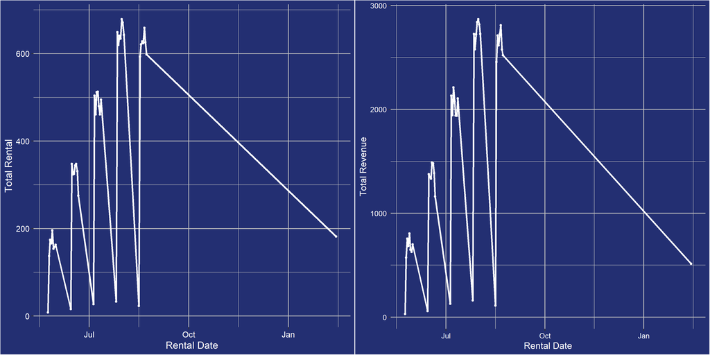

```r
grid.arrange(
  ggplot(
    data = truncated.daily.trend %>%
      select(`Rental Date`, `Total Rental`),
    aes(x = `Rental Date`, y = `Total Rental`)
  ) + geom_line(
    linewidth = 1,
    color = '#ffffff'
  ) + geom_point(
    size = 1,
    colour = '#ffffff'
  ) + theme (
    panel.background = element_rect(fill = '#232F72'),
    panel.grid = element_line(color = 'gray'),
    plot.background = element_rect(fill = '#232F72'),
    axis.title.x = element_text(color = '#ffffff', size = 12),
    axis.title.y = element_text(color = '#ffffff', size = 12),
    axis.text.x = element_text(color = '#ffffff', size = 10),
    axis.text.y = element_text(color = '#ffffff', size = 10)
  ),

  ggplot(
    data = truncated.daily.trend %>%
      select(`Rental Date`, `Total Revenue`),
    aes(x = `Rental Date`, y = `Total Revenue`)
  ) + geom_line(
    linewidth = 1,
    color = '#ffffff'
  ) + geom_point(
    size = 1,
    color = '#ffffff'
  ) + theme(
    panel.background = element_rect(fill = '#232F72'),
    panel.grid = element_line(color = 'gray'),
    plot.background = element_rect(fill = '#232F72'),
    axis.title.x = element_text(color = '#ffffff'),
    axis.title.y = element_text(color = '#ffffff'),
    axis.text.x = element_text(color = '#ffffff'),
    axis.text.y = element_text(color = '#ffffff')
  ),

  ncol = 2
)
```

#### Minat dan Revenue Terbaik Per-kategori

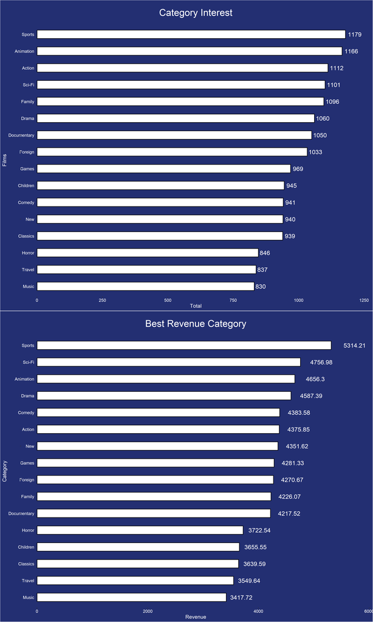

```r
popular.category <-category.film %>%
  group_by(Category) %>%
  count(Category) %>%
  ungroup() %>%
  arrange(desc(n))

revenue.category <-category.film %>%
  group_by(Category) %>%
  summarise(Revenue = sum(Amount)) %>%
  ungroup() %>%
  arrange(desc(Revenue))

grid.arrange(
  ggplot(
    data = popular.category,
    aes(x = fct_reorder(Category, n), y = n)
  ) + geom_col(
    width = 0.5,
    color = '#000000',
    fill = '#ffffff',
    linewidth = 0.6
  ) + coord_flip() + labs(
    title = 'Category Interest',
    x = 'Films',
    y = 'Total'
  ) + geom_text(
    aes(label = paste0(n)),
    size = 5,
    color = '#ffffff',
    position = position_stack(vjust = 1.03)
  ) + theme(
    plot.background = element_rect(fill = '#232F72'),
    panel.background = element_rect(fill = '#232F72'),
    panel.grid = element_blank(),
    plot.title = element_text(size = 22, hjust = 0.5, color = '#ffffff', margin = margin(t = 15, b = 15)),
    axis.title.x = element_text(color = '#ffffff', size = 12),
    axis.title.y = element_text(color = '#ffffff', size = 12),
    axis.text.x = element_text(color = '#ffffff', size = 10),
    axis.text.y = element_text(color = '#ffffff', size = 10, margin = margin(r = -33)),

  ),

  ggplot(
    data = revenue.category,
    aes(x = fct_reorder(Category, Revenue), y = Revenue)
  ) + geom_col(
    width = 0.5,
    color = '#000000',
    fill = '#ffffff',
    linewidth = 0.6
  ) + coord_flip() + labs(
    title = 'Best Revenue Category',
    x = 'Category',
    y = 'Revenue'
  ) + geom_text(
    aes(label = paste0(Revenue)),
    size = 5,
    color = '#ffffff',
    position = position_stack(vjust = 1.08)
  ) + theme(
    plot.background = element_rect(fill = '#232F72'),
    panel.background = element_rect(fill = '#232F72'),
    panel.grid = element_blank(),
    plot.title = element_text(size = 22, hjust = 0.5, color = '#ffffff', margin = margin(t = 15, b = 15)),
    axis.title.x = element_text(color = '#ffffff', size = 12),
    axis.title.y = element_text(color = '#ffffff', size = 12),
    axis.text.x = element_text(color = '#ffffff', size = 10),
    axis.text.y = element_text(color = '#ffffff', size = 10, margin = margin(r = -33)),

  ),

  ncol = 1
)
```

Grafik menunjukkan distribusi rental berdasarkan kategori. Genre Sports menjadi kategori paling diminati yang diikuti oleh Animation, Action, sementara genre Music menjadi kategori dengan peminat terendah. Genre lain terkumpul di tengah dengan selisih angka cenderung kecil, range berada dalam rentang [830,1179]. Genre Sport selain menjadi kategori paling diminati, kategori Sport juga menduduki *revenue* teratas. Hal ini mengindikasikan adanya segmen audiens yang besar pada genre tertentu sehingga adanya peluang untuk meningkatkan rental dan revenue film. Begitupun pada genre yang memiliki minat rendah menunjukkan adanya ruang untuk intervensi lebih dalam, seperti pemberian film berkualitas agar dapat meningkatkan angka minat pada kategori dengan minat rendah. Rekomendasi yang dapat diberikan adalah memaksimalkan performa dari kategori-kategori teratas melalui promosi menarik atau penawaran khusus terutama pada kategori yang memiliki volume rental tinggi dan diikuti dengan revenue yang tinggi dan melakukan uji intervensi pada genre-genre terendah dengan bundling paket film atau rekomendasi target.

#### Film Terlaris

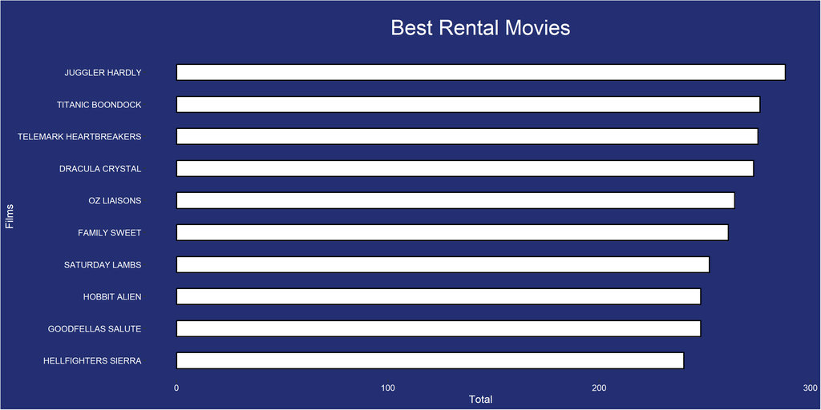

```r
popular.film <-film.actor %>%
  group_by(Title) %>%
  count(Title) %>%
  ungroup() %>%
  arrange(desc(n)) %>%
  slice_head(n = 10)

ggplot(
  data = popular.film,
  aes(x = fct_reorder(Title, n), y = n)
) + geom_col(
  width = 0.5,
  color = '#000000',
  fill = '#ffffff',
  linewidth = 0.6
) + coord_flip() + labs(
  title = 'Best Rental Movies',
  x = 'Films',
  y = 'Total'
) + theme(
  plot.background = element_rect(fill = '#232F72'),
  panel.background = element_rect(fill = '#232F72'),
  panel.grid = element_blank(),
  plot.title = element_text(size = 22, hjust = 0.5, color = '#ffffff', margin = margin(t = 15, b = 15)),
  axis.title.x = element_text(color = '#ffffff'),
  axis.title.y = element_text(color = '#ffffff'),
  axis.text.x = element_text(color = '#ffffff'),
  axis.text.y = element_text(color = '#ffffff')
)
```

Grafik menunjukkan film dengan judul Junggler Hardly menjadi film dengan rental terlaris, diikuti oleh Titanic Boondock, Telemark Heartbreakers, dan Hellfighters Sierra menjadi film urutan ke-10 terlaris. Selisih total rental antar film sangat kecil dan cenderung saling kompetitif satu sama lainnya. Hal ini menunjukkan faktor yang mungkin adalah kekuatan judul, alur, kualitas, promosi, atau rilis baru. Rekomendasi yang dapat diberikan adalah maksimalkan potensi dari keseluruhan film, tidak hanya terfokus pada film tertentu karena dari 10 film teratas terlihat posisi yang rapat.

#### Aktor Produktif

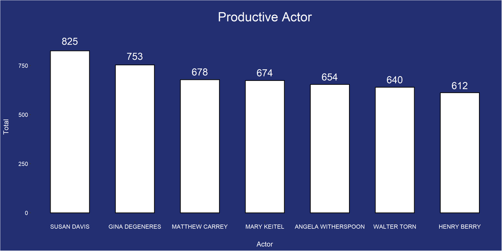

```r
productive.actor <-film.actor %>%
  group_by(Actor) %>%
  count(Actor) %>%
  ungroup() %>%
  arrange(desc(n)) %>%
  slice_head(n = 7)

ggplot(
  data = productive.actor,
  aes(x = fct_reorder(Actor, n, .desc = T), y = n)
) + geom_col(
  width = 0.6,
  color = '#000000',
  fill = '#ffffff',
  linewidth = 0.6
) + labs(
  title = 'Productive Actor',
  x = 'Actor',
  y = 'Total'
) + geom_text(
  aes(label = n),
  size = 6,
  color = '#ffffff',
  position = position_stack(vjust = 1.06)
) + theme(
  plot.background = element_rect(fill = '#232F72'),
  panel.background = element_rect(fill = '#232F72'),
  panel.grid = element_blank(),
  plot.title = element_text(size = 22, hjust = 0.5, color = '#ffffff', margin = margin(t = 15, b = 15)),
  axis.title.x = element_text(color = '#ffffff', size = 12, margin = margin(t = 20)),
  axis.title.y = element_text(color = '#ffffff', size = 12, margin = margin(r = 15)),
  axis.text.x = element_text(color = '#ffffff', size = 10),
  axis.text.y = element_text(color = '#ffffff', size = 10)
)
```

Susan Davis berada di puncak disusul oleh Gina Degeneres, dan Matthew Carrey. Henry Berry menjadi aktor dengan produktivitas terendah, sedangkan aktor yang berada di papan tengah memiliki daya saing yang ketat dan posisi cenderung rapat satu sama lain. Rentang nilai berada dalam [612,825]. Rekomendasi yang dapat diberikan adalah maksimalkan produktivitas Susan Davis untuk memerankan film, dapat juga melakukan kombinasi antara aktor yang ada di papan atas dengan aktor yang berada di papan tengah atau bawah.

### Segmentasi Pelanggan

#### Deteksi Multikolinearitas

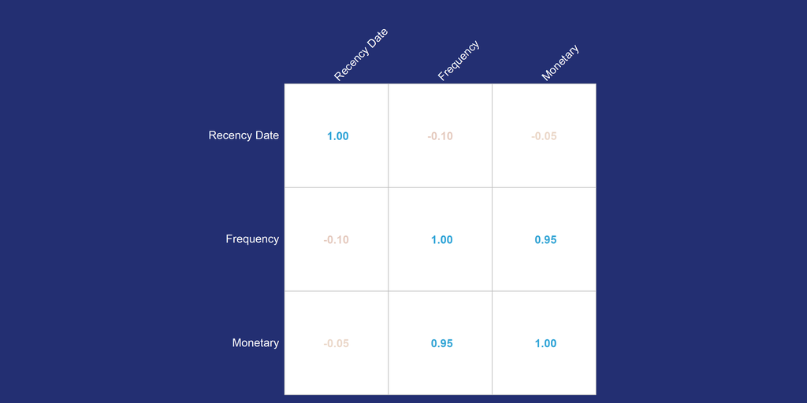

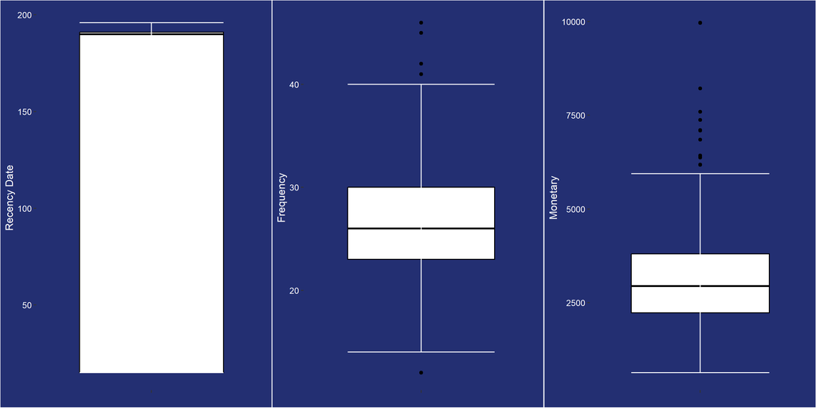

```r
par(
  bg = '#232F72',
  fg = '#ffffff',
  col.main = '#ffffff',
  col.lab = '#ffffff',
  col.axis = '#ffffff'
)

corrplot(
  cor(segment %>% select(`Recency Date`, Frequency, Monetary)),
  method = 'number',
  addCoef.col = '#ffffff',
  tl.col = '#ffffff',
  tl.srt = 45,
  cl.pos = 'n',
  col = colorRampPalette(c('#810B38', '#F1E2D1', '#2FA4D7'))(200),
  mar = c(0, 0, 2, 0)
)


grid.arrange(
  ggplot(
    data = segment %>% select(`Recency Date`),
    aes(x = '', y = `Recency Date`)
  ) + geom_boxplot(
    fill = '#ffffff',
    color = '#000000'
  ) + stat_boxplot(
    geom = 'errorbar',
    color = '#ffffff'
  ) + theme(
    plot.background = element_rect(fill = '#232F72'),
    panel.background = element_rect(fill = '#232F72'),
    panel.grid = element_blank(),
    axis.title.x = element_blank(),
    axis.title.y = element_text(color = '#ffffff'),
    axis.text.y = element_text(color = '#ffffff')
  ),

  ggplot(
    data = segment %>% select(Frequency),
    aes(x = '', y = Frequency)
  ) + geom_boxplot(
    fill = '#ffffff',
    color = '#000000'
  ) + stat_boxplot(
    geom = 'errorbar',
    color = '#ffffff'
  ) + theme(
    plot.background = element_rect(fill = '#232F72'),
    panel.background = element_rect(fill = '#232F72'),
    panel.grid = element_blank(),
    axis.title.x = element_blank(),
    axis.title.y = element_text(color = '#ffffff'),
    axis.text.y = element_text(color = '#ffffff')
  ),

  ggplot(
    data = segment %>% select(Monetary),
    aes(x = '', y = Monetary)
  ) + geom_boxplot(
    fill = '#ffffff',
    color = '#000000'
  ) + stat_boxplot(
    geom = 'errorbar',
    color = '#ffffff'
  ) + theme(
    plot.background = element_rect(fill = '#232F72'),
    panel.background = element_rect(fill = '#232F72'),
    panel.grid = element_blank(),
    axis.title.x = element_blank(),
    axis.title.y = element_text(color = '#ffffff'),
    axis.text.y = element_text(color = '#ffffff')
  ),

  ncol = 3
)

par(bg = '#ffffff')
```

#### *Handling* Outlier

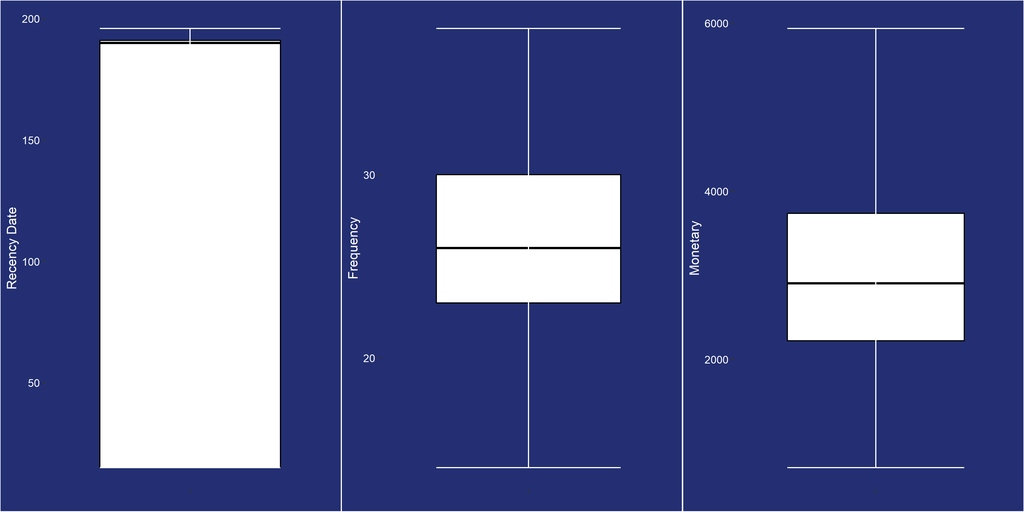

```r
trim.func <-function(col) {
  q1 <-quantile(x = col, probs = 0.25)
  q3 <-quantile(x = col, probs = 0.75)
  iqr <-q3-q1

  lower <- q1 - (1.5 * iqr)
  upper <-q3 + (1.5 * iqr)

  col <-if_else(between(x = col, left = lower, right = upper), col, NA)

  return(col)
}

segment <-segment %>%
  mutate(
    Frequency = trim.func(Frequency),
    Monetary = trim.func(Monetary)
  ) %>%
  filter(
    !is.na(Frequency),
    !is.na(Monetary)
  )

grid.arrange(
  ggplot(
    data = segment %>% select(`Recency Date`),
    aes(x = '', y = `Recency Date`)
  ) + geom_boxplot(
    fill = '#ffffff',
    color = '#000000'
  ) + stat_boxplot(
    geom = 'errorbar',
    color = '#ffffff'
  ) + theme(
    plot.background = element_rect(fill = '#232F72'),
    panel.background = element_rect(fill = '#232F72'),
    panel.grid = element_blank(),
    axis.title.x = element_blank(),
    axis.title.y = element_text(color = '#ffffff'),
    axis.text.y = element_text(color = '#ffffff')
  ),

  ggplot(
    data = segment %>% select(Frequency),
    aes(x = '', y = Frequency)
  ) + geom_boxplot(
    fill = '#ffffff',
    color = '#000000'
  ) + stat_boxplot(
    geom = 'errorbar',
    color = '#ffffff'
  ) + theme(
    plot.background = element_rect(fill = '#232F72'),
    panel.background = element_rect(fill = '#232F72'),
    panel.grid = element_blank(),
    axis.title.x = element_blank(),
    axis.title.y = element_text(color = '#ffffff'),
    axis.text.y = element_text(color = '#ffffff')
  ),

  ggplot(
    data = segment %>% select(Monetary),
    aes(x = '', y = Monetary)
  ) + geom_boxplot(
    fill = '#ffffff',
    color = '#000000'
  ) + stat_boxplot(
    geom = 'errorbar',
    color = '#ffffff'
  ) + theme(
    plot.background = element_rect(fill = '#232F72'),
    panel.background = element_rect(fill = '#232F72'),
    panel.grid = element_blank(),
    axis.title.x = element_blank(),
    axis.title.y = element_text(color = '#ffffff'),
    axis.text.y = element_text(color = '#ffffff')
  ),

  ncol = 3
)
```

Regresi Linear

```r
recipe.model <-recipe(Monetary ~ `Recency Date` + Frequency, data = segment) %>%
  step_nzv(all_numeric_predictors()) %>%
  step_BoxCox(all_outcomes())

prep.model <-recipe.model %>%
  prep(training = segment)

model <-linear_reg() %>%
  set_engine('lm')

workflow.model <-workflow() %>%
  add_recipe(recipe.model) %>%
  add_model(model)

fit.model <-workflow.model %>%
  fit(data = segment)

lm.engine <-fit.model %>%
  extract_fit_engine()

df.result <-lm.engine %>%
  augment(segment)

tidy(lm.engine)
glance(lm.engine)
```

```
## # A tibble: 3 × 5
##   term           estimate std.error statistic   p.value
##   <chr>             <dbl>     <dbl>     <dbl>     <dbl>
## 1 (Intercept)     1.31      1.26         1.04 2.98e-  1
## 2 `Recency Date`  0.00841   0.00262      3.21 1.38e-  3
## 3 Frequency       3.33      0.0433      76.9  1.30e-306
## # A tibble: 1 × 12
##   r.squared adj.r.squared sigma statistic   p.value    df logLik   AIC   BIC
##       <dbl>         <dbl> <dbl>     <dbl>     <dbl> <dbl>  <dbl> <dbl> <dbl>
## 1     0.911         0.910  4.86     2963. 1.65e-305     2 -1751. 3509. 3527.
## # ℹ 3 more variables: deviance <dbl>, df.residual <int>, nobs <int>
```

Model regresi linear berganda ditulis secara matematis sebagai: $$Y = \beta_0 + \beta_1 X_{1} + \beta_2 X_{2} + \epsilon$$ $$Y = 1,31 + 0,00841 X_{1} + 3,33 X_{2} + \epsilon$$

Dimana:

- Y = Variabel dependen (Monetary)
- X<sub>1</sub> = Variabel bebas pertama
- X<sub>2</sub> = Variabel bebas kedua
- β<sub>0</sub> = Intercept
- β<sub>1</sub>, β<sub>2</sub> = Koefisien regresi
- ε = Error random

Nilai R^2 sebesar 91,1% menunjukkan model cukup baik dalam menjelaskan variasi target oleh variabel prediktor.

#### Uji Asumsi Klasik

```r
shapiro.test(residuals(lm.engine))
```

```
##
##  Shapiro-Wilk normality test
##
## data:  residuals(lm.engine)
## W = 0.99804, p-value = 0.7501
```

```r
bptest(lm.engine)
```

```
##
##  studentized Breusch-Pagan test
##
## data:  lm.engine
## BP = 19.581, df = 2, p-value = 5.598e-05
```

```r
dwtest(lm.engine)
```

```
##
##  Durbin-Watson test
##
## data:  lm.engine
## DW = 2.0046, p-value = 0.5212
## alternative hypothesis: true autocorrelation is greater than 0
```

```r
vif(lm.engine)
```

```
## `Recency Date`      Frequency
##       1.009568       1.009568
```

### 1. Uji Normalitas

**Hipotesis:**
$$H_0:
\text{Data berdistribusi normal}$$
$$H_1: \text{Data tidak berdistribusi
normal}$$
**Tingkat Signifikansi:** $\alpha = 0,05$ **Daerah Kritis:** Tolak $H_0$ jika $p\text{-value} < 0,05$ **Hasil Uji:** $p\text{-value} = 0,7501$ **Keputusan:** Karena $p\text{-value} = 0,7501 > \alpha = 0,05$, maka **gagal tolak $H_0$**. **Kesimpulan:** Dengan interval kepercayaan 95%, data **berdistribusi normal**.

### 2. Uji Homoskedastisitas (Non-Heteroskedastisitas)

**Hipotesis:**
$$H_0:
\sigma^2_{\epsilon_i} = \sigma^2 \text{ (varians residual
konstan/homogen)}$$
$$H_1:
\sigma^2_{\epsilon_i} \neq \sigma^2 \text{ (varians residual tidak
konstan)}$$
**Tingkat Signifikansi:** $\alpha = 0,05$ **Daerah Kritis:** Tolak $H_0$ jika $p\text{-value} < 0,05$ **Hasil Uji:** $p\text{-value} = 5,598e-05$ **Keputusan:** Karena $p\text{-value} = 5,598e-05 < \alpha = 0,05$, maka **tolak $H_0$**. **Kesimpulan:** Dengan interval kepercayaan 95%, varians residual **tidak bersifat konstan** (terdapat heteroskedastisitas).

### 3. Uji Autokorelasi (Non-Autokorelasi)

**Hipotesis:**
$$H_0: \rho =
0 \text{ (tidak terdapat autokorelasi)}$$
$$H_1: \rho \neq 0 \text{ (terdapat
autokorelasi)}$$
**Tingkat Signifikansi:** $\alpha = 0,05$ **Daerah Kritis:** Tolak $H_0$ jika $p\text{-value} < 0,05$ **Hasil Uji:** $p\text{-value} = 0,5212$ **Keputusan:** Karena $p\text{-value} = 0,5212 > \alpha = 0,05$, maka **gagal tolak $H_0$**. **Kesimpulan:** Tidak terdapat autokorelasi dalam residual model.

### 4. Uji Multikolinearitas

**Hipotesis:**
$$H_0:
\text{VIF} \approx 1 \text{ (tidak terdapat multikolinearitas)}$$
$$H_1: \text{VIF} > 10 \text{ (terdapat
multikolinearitas)}$$
**Daerah Kritis:** Tolak $H_0$ jika $\text{VIF} > 10$ **Hasil Uji:** - $\text{VIF}_{X_1} = 1,009568$ - $\text{VIF}_{X_2} = 1,009568$ **Keputusan:** Karena $\text{VIF}_{X_1} = 1,009568 < 10$ dan $\text{VIF}_{X_2} = 1,009568 < 10$, maka **gagal tolak $H_0$**. **Kesimpulan:** Tidak terdapat multikolinearitas antar variabel dalam model regresi.

#### Cek Leverage dan Cook's Distance

```r
threshold.leverage <-2 * length(coefficients(lm.engine)) / segment %>%
  select(`Recency Date`, Frequency, Monetary) %>%
  summarise(n = n()) %>%
  pull(n)

threshold.cooks.distance <-4 / segment %>%
  select(`Recency Date`, Frequency, Monetary) %>%
  summarise(n = n()) %>%
  pull(n)

print(round(threshold.leverage, 3))
print(round(threshold.cooks.distance, 3))

df.result <-df.result %>%
  mutate(
    flag.leverage = .hat > threshold.leverage,
    flag.cook.distance = .cooksd > threshold.cooks.distance
  )

df.result %>%
  select(flag.cook.distance) %>%
  filter(flag.cook.distance == T)
```

```
## [1] 0.01
## [1] 0.007
## # A tibble: 31 × 1
##    flag.cook.distance
##    <lgl>
##  1 TRUE
##  2 TRUE
##  3 TRUE
##  4 TRUE
##  5 TRUE
##  6 TRUE
##  7 TRUE
##  8 TRUE
##  9 TRUE
## 10 TRUE
## # ℹ 21 more rows
```

#### *Handling* Leverage dan Cook's Distance

```r
threshold.leverage.fit.last <-2 * length(coefficients(lm.engine.fit.last)) / segment.last %>%
  select(`Recency Date`, Frequency, Monetary) %>%
  summarise(n = n()) %>%
  pull(n)

threshold.cooks.distance.fit.last <-4 / segment.last %>%
  select(`Recency Date`, Frequency, Monetary) %>%
  summarise(n = n()) %>%
  pull(n)

print(round(threshold.leverage.fit.last, 3))
```

[output not shown]

```
## [1] 0.012
```

```r
print(round(threshold.cooks.distance.fit.last, 3))
```

```
## [1] 0.008
```

```r
df.result.fit.last <-df.result.fit.last %>%
  mutate(
    flag.leverage = .hat > threshold.leverage.fit,
    flag.cook.distance = .cooksd > threshold.cooks.distance.fit
  )

df.result.fit.last %>%
  select(flag.cook.distance) %>%
  filter(flag.cook.distance == T)
```

```
## # A tibble: 2 × 1
##   flag.cook.distance
##   <lgl>
## 1 TRUE
## 2 TRUE
```

#### Model Regresi Final

```r
segment.final <-df.result.fit.last %>%
  filter(!flag.cook.distance == T) %>%
  select(`Recency Date`, Frequency, Monetary)

recipe.fit.final <-recipe(Monetary ~ `Recency Date` + Frequency, data = segment.final) %>%
  step_nzv(all_numeric_predictors()) %>%
  step_BoxCox(all_outcomes())

prep.model.final <-recipe.fit.final %>%
  prep(training = segment)

model.fit.final <-linear_reg() %>%
  set_engine('lm')

workflow.fit.final <-workflow() %>%
  add_recipe(recipe.fit.final) %>%
  add_model(model.fit.final)

fit.model.final <-workflow.fit.final %>%
  fit(data = segment.final %>% select(Monetary, `Recency Date`, Frequency))

lm.engine.fit.final <-fit.model.final%>%
  extract_fit_engine()

df.result.fit.final <-lm.engine.fit.final %>%
  augment(segment.final %>% select(Monetary, `Recency Date`, Frequency))

tidy(lm.engine.fit.final)
```

```
## # A tibble: 3 × 5
##   term           estimate std.error statistic   p.value
##   <chr>             <dbl>     <dbl>     <dbl>     <dbl>
## 1 (Intercept)     2.04      1.07         1.91 5.63e-  2
## 2 `Recency Date`  0.00795   0.00224      3.56 4.13e-  4
## 3 Frequency       3.20      0.0370      86.4  6.81e-308
```

```r
glance(lm.engine.fit.final)
```

```
## # A tibble: 1 × 12
##   r.squared adj.r.squared sigma statistic   p.value    df logLik   AIC   BIC
##       <dbl>         <dbl> <dbl>     <dbl>     <dbl> <dbl>  <dbl> <dbl> <dbl>
## 1     0.936         0.936  3.72     3744. 9.90e-307     2 -1408. 2825. 2842.
## # ℹ 3 more variables: deviance <dbl>, df.residual <int>, nobs <int>
```

Model regresi linear berganda ditulis kembali secara matematis sebagai: $$Y = \beta_0 + \beta_1 X_{1} + \beta_2 X_{2} + \epsilon$$ \begin{equation} \hat{Y}_i = 2.04 + 0.00795 X_{1i} + 3.2 X_{2i} \end{equation}

Dimana:

- Y = Variabel dependen (Monetary)
- X<sub>1</sub> = Variabel bebas pertama
- X<sub>2</sub> = Variabel bebas kedua
- β<sub>0</sub> = Intercept
- β<sub>1</sub>, β<sub>2</sub> = Koefisien regresi
- ε = Error random

Nilai R^2 sebesar 93,6% menunjukkan model cukup baik dalam menjelaskan variasi target oleh variabel prediktor.

#### Cek Asumsi Final

```r
shapiro.test(residuals(lm.engine.fit.final))
```

```
##
##  Shapiro-Wilk normality test
##
## data:  residuals(lm.engine.fit.final)
## W = 0.99527, p-value = 0.1174
```

```r
bptest(lm.engine.fit.final)
```

```
##
##  studentized Breusch-Pagan test
##
## data:  lm.engine.fit.final
## BP = 14.663, df = 2, p-value = 0.0006546
```

```r
dwtest(lm.engine.fit.final)
```

```
##
##  Durbin-Watson test
##
## data:  lm.engine.fit.final
## DW = 1.9217, p-value = 0.186
## alternative hypothesis: true autocorrelation is greater than 0
```

```r
vif(lm.engine.fit.final)
```

```
## `Recency Date`      Frequency
##       1.008624       1.008624
```

### 1. Uji Normalitas

**Hipotesis:**
$$H_0:
\text{Data berdistribusi normal}$$
$$H_1: \text{Data tidak berdistribusi
normal}$$
**Tingkat Signifikansi:** $\alpha = 0,05$ **Daerah Kritis:** Tolak $H_0$ jika $p\text{-value} < 0,05$ **Hasil Uji:** $p\text{-value} = 0,1174$ **Keputusan:** Karena $p\text{-value} = 0,1174 > \alpha = 0,05$, maka **gagal tolak $H_0$**. **Kesimpulan:** Dengan interval kepercayaan 95%, data **berdistribusi normal**.

### 2. Uji Homoskedastisitas (Non-Heteroskedastisitas)

**Hipotesis:**
$$H_0:
\sigma^2_{\epsilon_i} = \sigma^2 \text{ (varians residual
konstan/homogen)}$$
$$H_1:
\sigma^2_{\epsilon_i} \neq \sigma^2 \text{ (varians residual tidak
konstan)}$$
**Tingkat Signifikansi:** $\alpha = 0,05$ **Daerah Kritis:** Tolak $H_0$ jika $p\text{-value} < 0,05$ **Hasil Uji:** $p\text{-value} = 0,0006546$ **Keputusan:** Karena $p\text{-value} = 0,0006546 < \alpha = 0,05$, maka **tolak $H_0$**. **Kesimpulan:** Dengan interval kepercayaan 95%, varians residual **tidak bersifat konstan** (terdapat heteroskedastisitas).

### 3. Uji Autokorelasi (Non-Autokorelasi)

**Hipotesis:**
$$H_0: \rho =
0 \text{ (tidak terdapat autokorelasi)}$$
$$H_1: \rho \neq 0 \text{ (terdapat
autokorelasi)}$$
**Tingkat Signifikansi:** $\alpha = 0,05$ **Daerah Kritis:** Tolak $H_0$ jika $p\text{-value} < 0,05$ **Hasil Uji:** $p\text{-value} = 0,186$ **Keputusan:** Karena $p\text{-value} = 0,186 > \alpha = 0,05$, maka **gagal tolak $H_0$**. **Kesimpulan:** Tidak terdapat autokorelasi dalam residual model.

### 4. Uji Multikolinearitas

**Hipotesis:**
$$H_0:
\text{VIF} \approx 1 \text{ (tidak terdapat multikolinearitas)}$$
$$H_1: \text{VIF} > 10 \text{ (terdapat
multikolinearitas)}$$
**Daerah Kritis:** Tolak $H_0$ jika $\text{VIF} > 10$ **Hasil Uji:** - $\text{VIF}_{X_1} = 1,008624$ - $\text{VIF}_{X_2} = 1,008624$ **Keputusan:** Karena $\text{VIF}_{X_1} = 1,008624 < 10$ dan $\text{VIF}_{X_2} = 1,008624 < 10$, maka **gagal tolak $H_0$**. **Kesimpulan:** Tidak terdapat multikolinearitas antar variabel dalam model regresi.

```r
threshold.leverage.fit.final <-2 * length(coefficients(lm.engine.fit.final)) / segment.final %>%
  select(`Recency Date`, Frequency, Monetary) %>%
  summarise(n = n()) %>%
  pull(n)

threshold.cooks.distance.fit.final <-4 / segment.final %>%
  select(`Recency Date`, Frequency, Monetary) %>%
  summarise(n = n()) %>%
  pull(n)

print(round(threshold.leverage.fit.final, 3))
```

```
## [1] 0.012
```

```r
print(round(threshold.cooks.distance.fit.final, 3))
```

```
## [1] 0.008
```

```r
df.result.fit.final <-df.result.fit.final %>%
  mutate(
    flag.leverage = .hat > threshold.leverage.fit,
    flag.cook.distance = .cooksd > threshold.cooks.distance.fit
  )

df.result.fit.final %>%
  select(flag.cook.distance) %>%
  filter(flag.cook.distance == T)
```

```
## # A tibble: 0 × 1
## # ℹ 1 variable: flag.cook.distance <lgl>
```

#### Standar Eror Robust

```r
coeftest(
  x = lm.engine.fit.final,
  vcov. = vcovHC(lm.engine.fit.final, type = 'HC2')
)
```

```
##
## t test of coefficients:
##
##                 Estimate Std. Error  t value  Pr(>|t|)
## (Intercept)    2.0413438  0.8880572   2.2987   0.02193 *
## `Recency Date` 0.0079517  0.0019239   4.1331  4.18e-05 ***
## Frequency      3.1964787  0.0314175 101.7421 < 2.2e-16 ***
## ---
## Signif. codes:  0 '***' 0.001 '**' 0.01 '*' 0.05 '.' 0.1 ' ' 1
```

Berdasarkan metode Standar Eror Robust, secara inferensi dapat dikatakan valid sehingga didapatkan:

\begin{equation} H_0: \beta_j = 0 \quad \text{(Variabel } X_j \text{ tidak berpengaruh signifikan terhadap } Y) \end{equation}

\begin{equation} H_1: \beta_j \neq 0 \quad \text{(Variabel } X_j \text{ berpengaruh signifikan terhadap } Y) \end{equation}

\alpha: 0,05

Daerah Kritis: H_0 ditolak jika p-value < 0,05

#### *Reverse* Tipe Data Asli

```r
recipe.fit.final$steps %>%
  map_lgl(function(x) inherits(x, 'step_BoxCox')) %>%
  which()
```

```
## [1] 2
```

```r
lambda <-tidy(prep.model.final, number = 2) %>%
  select(value) %>%
  pull(value)

segment.final <-df.result.fit.final %>%
  select(Monetary, `Recency Date`, Frequency, .fitted) %>%
  mutate(
    Mresidual = BoxCox(Monetary, lambda = lambda) - .fitted,
    `Monetary Predict` = InvBoxCox(x = .fitted, lambda = lambda),
    Residual = Monetary - `Monetary Predict`
  )

print(segment.final)
```

```
## # A tibble: 516 × 7
##    Monetary `Recency Date` Frequency .fitted Mresidual `Monetary Predict`
##       <dbl>          <dbl>     <dbl>   <dbl>     <dbl>              <dbl>
##  1    3798.            191        32   106.     -2.87               4020.
##  2    3476.            190        27    89.9     8.80               2867.
##  3    3529.            190        26    86.7    12.7                2661.
##  4    1799.            190        22    73.9    -2.25               1917.
##  5    2624.            190        28    93.1    -6.97               3081.
##  6    5005.            192        33   109.      8.63               4275.
##  7    2226.            190        24    80.3    -0.803              2273.
##  8    2065.             15        23    75.7     0.923              2014.
##  9    2494.            191        25    83.5     0.503              2463.
## 10    2562.             15        24    78.9     6.21               2192.
## # ℹ 506 more rows
## # ℹ 1 more variable: Residual <dbl>
```

#### Cek Multikolinear Final

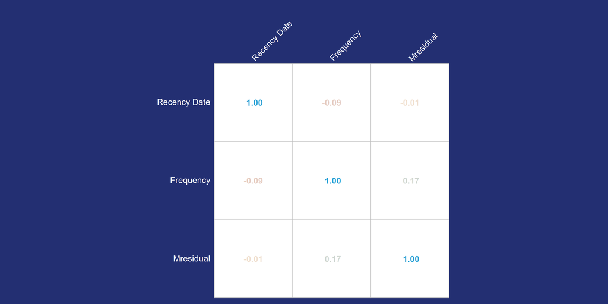

```r
par(
  bg = '#232F72',
  fg = '#ffffff',
  col.main = '#ffffff',
  col.lab = '#ffffff',
  col.axis = '#ffffff'
)

corrplot(
  cor(segment.final %>% select(`Recency Date`, Frequency, Mresidual)),
  method = 'number',
  addCoef.col = '#ffffff',
  tl.col = '#ffffff',
  tl.srt = 45,
  cl.pos = 'n',
  col = colorRampPalette(c('#810B38', '#F1E2D1', '#2FA4D7'))(200),
  mar = c(0, 0, 2, 0)
)
```

```r
par(bg = '#ffffff')
```

#### Clustering

```r
recipe.clustering <-recipe(~ `Recency Date` + Frequency + Mresidual, data = segment.final) %>%
  step_nzv(all_numeric_predictors()) %>%
  step_normalize(all_numeric_predictors())

cluster.model <-hier_clust(
  num_clusters = 5,
  linkage_method = 'ward.D2'
) %>%
  set_engine('stats')

workflow.cluster <-workflow() %>%
  add_recipe(recipe.clustering) %>%
  add_model(cluster.model)

fit.cluster <-workflow.cluster %>%
  fit(data =  segment.final)

cluster <-fit.cluster %>%
  predict(segment.final) %>%
  pull(.pred_cluster)

cluster.result <-segment.final %>%
  mutate(Cluster = cluster)

print(cluster.result)
```

```
## # A tibble: 516 × 8
##    Monetary `Recency Date` Frequency .fitted Mresidual `Monetary Predict`
##       <dbl>          <dbl>     <dbl>   <dbl>     <dbl>              <dbl>
##  1    3798.            191        32   106.     -2.87               4020.
##  2    3476.            190        27    89.9     8.80               2867.
##  3    3529.            190        26    86.7    12.7                2661.
##  4    1799.            190        22    73.9    -2.25               1917.
##  5    2624.            190        28    93.1    -6.97               3081.
##  6    5005.            192        33   109.      8.63               4275.
##  7    2226.            190        24    80.3    -0.803              2273.
##  8    2065.             15        23    75.7     0.923              2014.
##  9    2494.            191        25    83.5     0.503              2463.
## 10    2562.             15        24    78.9     6.21               2192.
## # ℹ 506 more rows
## # ℹ 2 more variables: Residual <dbl>, Cluster <fct>
```

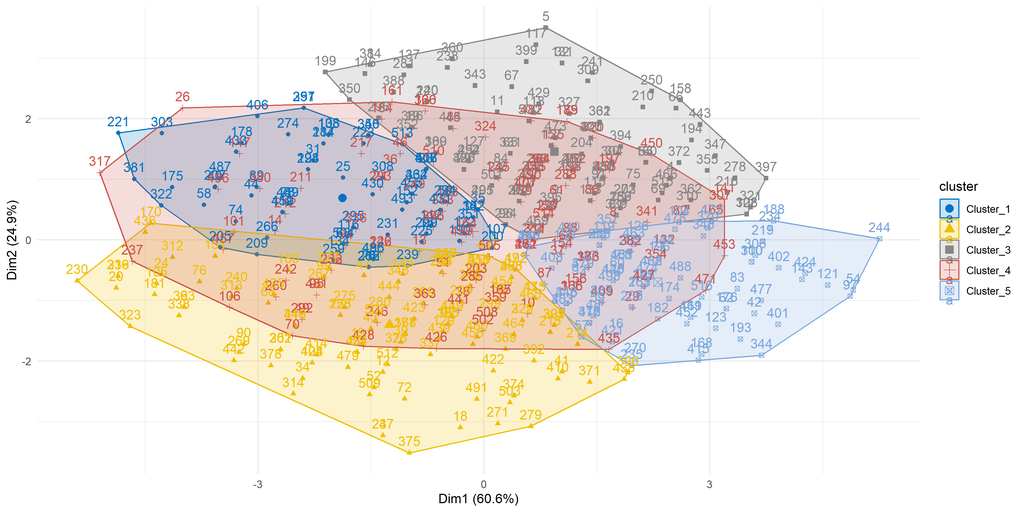

```r
fviz_cluster(
  list(data = segment.final, cluster = cluster.result$Cluster),
  palette = 'jco',
  main = NULL
) + theme_minimal()
```

```r
median.recency <-segment.final %>%
  summarise(median.r = median(`Recency Date`)) %>%
  pull(median.r)

median.frequency <-segment.final %>%
  summarise(median.f = median(Frequency)) %>%
  pull(median.f)

median.mresidual <-segment.final %>%
  summarise(median.mr = median(Mresidual)) %>%
  pull(median.mr)

cluster.result <-segment.final %>%
  mutate(
    r.category = if_else(`Recency Date` <= median.recency, 'low', 'high'),
    f.category = if_else(Frequency <= median.frequency, 'low', 'high'),
    mr.category = case_when(
      Mresidual <= quantile(x = Mresidual, probs = 0.25) ~ 'low',
      Mresidual >= quantile(x = Mresidual, probs = 0.75) ~ 'high',
      T ~ 'med'
    ),

    Cluster = cluster,

    Segmentation = case_when(
      r.category == 'low' & f.category == 'high' & mr.category == 'high' ~ 'Champions',
      r.category == 'low' & f.category == 'high' & mr.category == 'med' ~ 'Loyal Customers',
      r.category == 'low' & f.category == 'low' & mr.category == 'high' ~ 'Potential Loyal',
      r.category == 'low' & f.category == 'low' & mr.category %in% c('med', 'high') ~ 'New Customers',
      `Recency Date` < quantile(x = `Recency Date`, probs = 0.6) & Frequency > quantile(x = Frequency,
          probs = 0.4) & mr.category == 'high' ~ 'Promising',
      `Recency Date` < quantile(x = `Recency Date`, 0.6) & Frequency > quantile(x = Frequency,
          probs = 0.4) & mr.category == 'low' ~ 'Need Attention',
      r.category == 'high' & f.category == 'high' & mr.category == 'high' ~ 'Cannot Lose Them',
      r.category == 'high' & f.category == 'high' & mr.category == 'low' ~ 'At Risk',
      r.category == 'high' & f.category == 'low' & mr.category == 'med' ~ 'About To Sleep',
      r.category == 'high' & f.category == 'high' & mr.category == 'low' ~ 'Hibernating',
      `Recency Date` > quantile(x = `Recency Date`, probs = 0.75) & Frequency < quantile(x = Frequency,
          probs = 0.25) ~ 'Lost',
      T ~ 'Others'
    )
  ) %>%
  select(-c(.fitted, Mresidual, `Monetary Predict`, Residual, r.category, f.category, mr.category))

head(cluster.result, 20)
```

```
## # A tibble: 20 × 5
##    Monetary `Recency Date` Frequency Cluster   Segmentation
##       <dbl>          <dbl>     <dbl> <fct>     <chr>
##  1    3798.            191        32 Cluster_3 At Risk
##  2    3476.            190        27 Cluster_2 Champions
##  3    3529.            190        26 Cluster_2 Potential Loyal
##  4    1799.            190        22 Cluster_3 Others
##  5    2624.            190        28 Cluster_3 Others
##  6    5005.            192        33 Cluster_2 Cannot Lose Them
##  7    2226.            190        24 Cluster_3 Others
##  8    2065.             15        23 Cluster_4 New Customers
##  9    2494.            191        25 Cluster_3 About To Sleep
## 10    2562.             15        24 Cluster_4 Potential Loyal
## 11    2904.            190        28 Cluster_3 Others
## 12    3557.            191        27 Cluster_2 Cannot Lose Them
## 13    3296.             15        28 Cluster_4 Loyal Customers
## 14    4310.             15        32 Cluster_4 Loyal Customers
## 15    3324.            192        28 Cluster_1 Others
## 16    2075.            190        21 Cluster_5 Potential Loyal
## 17    2019.            193        22 Cluster_5 About To Sleep
## 18    3018.            190        24 Cluster_2 Potential Loyal
## 19    3471             190        30 Cluster_3 Others
## 20    5448.             15        35 Cluster_2 Champions
```

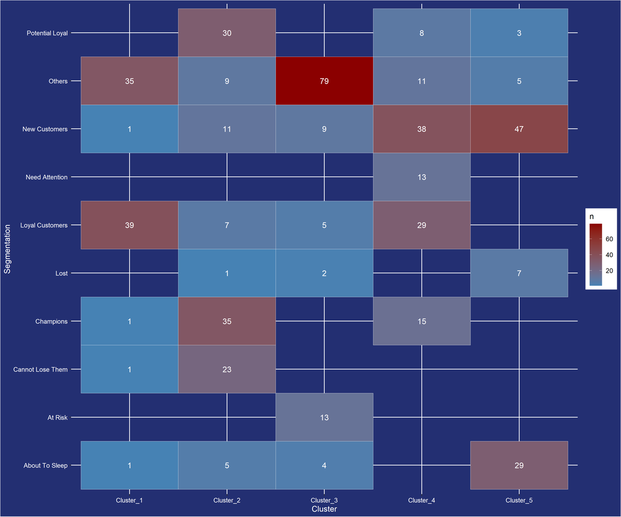

```r
ggplot(
  data = cluster.result %>%
    count(Cluster, Segmentation),
  aes(x = Cluster, y = Segmentation, fill = n)
) + geom_tile(
  color = '#ffffff'
) + geom_text(
  aes(label = n),
  color = '#ffffff'
) + scale_fill_gradient(
  low = 'steelblue',
  high = 'darkred'
) + theme(
  panel.background = element_rect(fill = '#232F72'),
  plot.background = element_rect(fill = '#232F72'),
  axis.title.x = element_text(color = '#ffffff'),
  axis.title.y = element_text(color = '#ffffff'),
  axis.text.x = element_text(color = '#ffffff'),
  axis.text.y = element_text(color = '#ffffff')
)
```